# Rivadavia_Chagas

MPF

2024-08-29

## Introduction

In this guide, we will walk through the analysis of a dataset from Rivadavia.

- **Loading the Dataset**: Initial step to load and summarize the dataset.
- **Data Preprocessing**: Handling missing values, converting variables, and preparing the data for analysis.
- **Subsetting the Data**: Focusing on specific cases within the dataset.
- **Visualization**: Creating stacked bar plots to understand categorical variables.
- **Cross-Tabulations**: Exploring relationships between categorical variables.
- **Logistic Regression**: Fitting a model to predict the outcome variable and interpreting the results.
- **Visualization of Predictions**: Understanding the model’s predictions through visualization.
- **Conclusion**: Summarizing the entire analysis and highlighting key insights.

This R Markdown file will generate a comprehensive HTML report that details each step of your analysis, including discussions that explain the purpose and findings of each chunk of code. If you have further requirements or specific points you’d like to focus on, feel free to ask!

### Load data and packages

```r
# Clear the workspace
rm(list=ls())

#load packages needed
library(ggplot2)
library(gridExtra)
library(dplyr)
library(knitr)
library(kableExtra)
library(FactoMineR)
library(factoextra)
library(corrplot)
library(missMDA)
library(cluster)
library(vcd)
library(logistf)
library(MuMIn)
library(Hmisc)
# Disable scientific notation globally
options(scipen = 999)

# Load the dataset
db <- read.csv(here::here("dbrivadavia.csv"))
```

### Pre-process data

```r
# Remove rows with missing values(NA) in the first column
db <- subset(db, !is.na(db[,1]))

# List of categorical variables
cat_vars <- c("ID",
              "Block",
              "Unit",
              "STATUS",
              "INF",
              "SITE",
              "SPR",
              "wall_material",
              "wall_covering",
              "roof_material",
              "roof_covering",
              "watertank",
              "watertank_pigeon",
              "palm",
              "objects",
              "insecticide",
              "commercial",
              "permethrin",
              "other",
              "travel_rural",
              "dwelling_status",
              "chicken_coop",
              "rats",
              "idcerca_NE",
              "idcerca_NW",
              "idcerca_S")

# Convert categorical variables to factors
db[cat_vars] <- lapply(db[cat_vars], as.factor)

# Convert the Date column from character to Date
db$DATE <- as.Date(db$DATE, format = "%d/%m/%Y")
db$SPR.DATE <- as.Date(db$SPR.DATE, format = "%d/%m/%Y")

#subset database to select only houses that have been inspected for triatomine infestations (EV)

dbEV <- subset(db,db$STATUS == "EV")
```

### Descriptive analyses

First, we visualize the categorical explanatory variables againts the infested status of the household (INF)

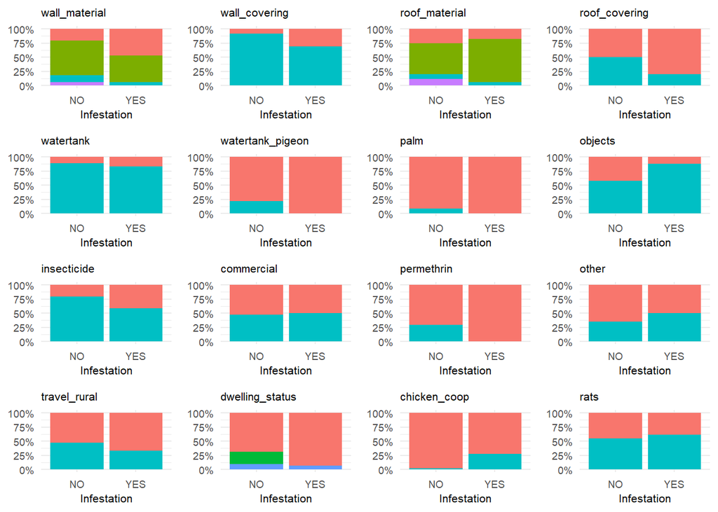

```r
# Function to create stacked bar plots and ignore NAs
create_stacked_bar_plot <- function(data, categorical_var, target_var) {
  # Remove rows with NA in the current categorical variable
  data <- data[!is.na(data[[categorical_var]]), ]

  ggplot(data, aes_string(x = target_var, fill = categorical_var)) +
    geom_bar(position = "fill") +
    scale_y_continuous(labels = scales::percent_format()) +
    labs(y = NULL, fill = categorical_var, x = "Infestation") +
    theme_minimal() +
    theme(legend.position = "none",
              plot.title = element_text(size = 8),
              axis.title.x = element_text(size = 8),
              axis.title.y = element_text(size = 8),
              axis.text.x = element_text(size = 7),
              axis.text.y = element_text(size = 7)
            ) +
    ggtitle(categorical_var)
}

# Create list of categorical variables to visualize
categorical_vars <- setdiff(cat_vars, c(
                            "ID",
                            "Block",
                            "Unit",
                            "STATUS",
                            "INF",
                            "SITE",
                            "SPR",
                            "education_level",
                            "employer",
                            "employee",
                            "selfemployed",
                            "housework",
                            "not.employed",
                            "pension",
                            "benefit",
                            "health",
                            "idcerca_NE",
                            "idcerca_NW",
                            "idcerca_S"))

# Create a list to store the plots
cat_plots <- list()

# Convert INF variable to a factor with labels "NO" and "YES"
dbEV$INF_label <- factor(dbEV$INF, levels = c(0, 1), labels = c("NO", "YES"))

# Create plots for each remaining categorical variable and store in the list
for (var in categorical_vars) {
  cat_plots[[var]] <- create_stacked_bar_plot(dbEV, var, "INF_label")
}

# Arrange the plots in a 4x4 grid
grid.arrange(grobs = cat_plots, ncol = 4, nrow = 4)
```

```r
# Initialize an empty data frame to store results
contingency_results <- data.frame(Variable = character(),
                                  Category = character(),
                                  No_Infestation = numeric(),
                                  Yes_Infestation = numeric(),
                                  stringsAsFactors = FALSE)

# Perform Fisher's exact test and calculate proportions for each categorical variable
for (var in categorical_vars) {
  # Create a contingency table
  contingency_table <- table(dbEV[[var]], dbEV$INF)

  # Calculate proportions
  prop_table <- prop.table(contingency_table, margin = 2)

  # Store results with proportions
  for (level in rownames(contingency_table)) {
    contingency_results <- rbind(contingency_results, data.frame(
      Variable = var,
      Category = level,
      No_Infestation = prop_table[level, "0"],
      Yes_Infestation = prop_table[level, "1"]
    ))
  }
}

# Format and display the results as a table
contingency_results %>%
  mutate(No_Infestation = scales::percent(No_Infestation, accuracy = 0.1),
         Yes_Infestation = scales::percent(Yes_Infestation, accuracy = 0.1)) %>%
  kable("html", col.names = c("Variable", "Category", "No Infestation", "Yes Infestation"), align = "c") %>%
  kable_styling(full_width = FALSE, position = "left",
                bootstrap_options = c("striped", "hover", "condensed")) %>%
  column_spec(1, color = "black") %>%
  column_spec(2, color = "black") %>%
  column_spec(3, color = "black") %>%
  column_spec(4, color = "black") %>%
  row_spec(0, bold = TRUE, color = "black")
```

| Variable | Category | No Infestation | Yes Infestation |
| --- | --- | --- | --- |
| wall_material | 1 | 21.1% | 47.1% |
| wall_material | 2 | 61.2% | 47.1% |
| wall_material | 3 | 11.6% | 5.9% |
| wall_material | 4 | 6.1% | 0.0% |
| wall_covering | 0 | 8.9% | 30.8% |
| wall_covering | 1 | 91.1% | 69.2% |
| roof_material | 1 | 25.0% | 17.6% |
| roof_material | 2 | 55.6% | 76.5% |
| roof_material | 3 | 8.3% | 5.9% |
| roof_material | 4 | 11.1% | 0.0% |
| roof_covering | 0 | 50.0% | 80.0% |
| roof_covering | 1 | 50.0% | 20.0% |
| watertank | 0 | 11.7% | 16.7% |
| watertank | 1 | 88.3% | 83.3% |
| watertank_pigeon | 0 | 78.1% | 100.0% |
| watertank_pigeon | 1 | 21.9% | 0.0% |
| palm | 0 | 91.4% | 100.0% |
| palm | 1 | 8.6% | 0.0% |
| objects | 0 | 42.3% | 12.5% |
| objects | 1 | 57.7% | 87.5% |
| insecticide | 0 | 20.4% | 41.2% |
| insecticide | 1 | 79.6% | 58.8% |
| commercial | 0 | 53.1% | 50.0% |
| commercial | 1 | 46.9% | 50.0% |
| permethrin | 0 | 70.8% | 100.0% |
| permethrin | 1 | 29.2% | 0.0% |
| other | 0 | 64.6% | 50.0% |
| other | 1 | 35.4% | 50.0% |
| travel_rural | 0 | 53.1% | 66.7% |
| travel_rural | 1 | 46.9% | 33.3% |
| dwelling_status | 1 | 68.8% | 93.3% |
| dwelling_status | 2 | 22.1% | 0.0% |
| dwelling_status | 3 | 9.1% | 6.7% |
| chicken_coop | 0 | 98.1% | 72.2% |
| chicken_coop | 1 | 1.9% | 27.8% |
| rats | 0 | 45.2% | 38.9% |
| rats | 1 | 54.8% | 61.1% |

We perform Fisher’s exact test for each categorical variable to check for significant associations with the `INF` variable.

```r
# Initialize an empty data frame to store results
fisher_results <- data.frame(Variable = character(),
                             p_value = numeric(),
                             stringsAsFactors = FALSE)

# Perform Fisher's exact test for each categorical variable
for (var in categorical_vars) {
  test_result <- fisher.test(table(dbEV[[var]], dbEV$INF))
  fisher_results <- rbind(fisher_results, data.frame(Variable = var, p_value = test_result$p.value))
}

# Display the results
fisher_results <- fisher_results %>%
  mutate(Significance = case_when(
    p_value < 0.001 ~ "***",
    p_value < 0.01 ~ "**",
    p_value < 0.05 ~ "*",
    TRUE ~ ""
  ))

# Format and display the results as a table
fisher_results %>%
  mutate(p_value = formatC(p_value, format = "f", digits = 4)) %>%
  kable("html", col.names = c("Variable", "P-value", "Significance"), align = "c") %>%
  kable_styling(full_width = FALSE, position = "left",
                bootstrap_options = c("striped", "hover", "condensed")) %>%
  column_spec(1, color = "black") %>%
  column_spec(2, color = "black") %>%
  column_spec(3, bold = TRUE, color = "red") %>%
   row_spec(which(fisher_results$Significance != ""), bold = TRUE) %>%
  row_spec(0, bold = TRUE, color = "black")
```

Variable

P-value

Significance

wall_material

0.1474

wall_covering

0.0372

roof_material

0.3866

roof_covering

0.0498

watertank

0.4649

watertank_pigeon

0.0256

palm

0.3651

objects

0.0288

insecticide

0.0660

commercial

1.0000

permethrin

1.0000

other

1.0000

travel_rural

0.3248

dwelling_status

0.0893

chicken_coop

0.0003

***

rats

0.8029

Next, we visualize the numeric explanatory variables against the infested status of the household (INF)

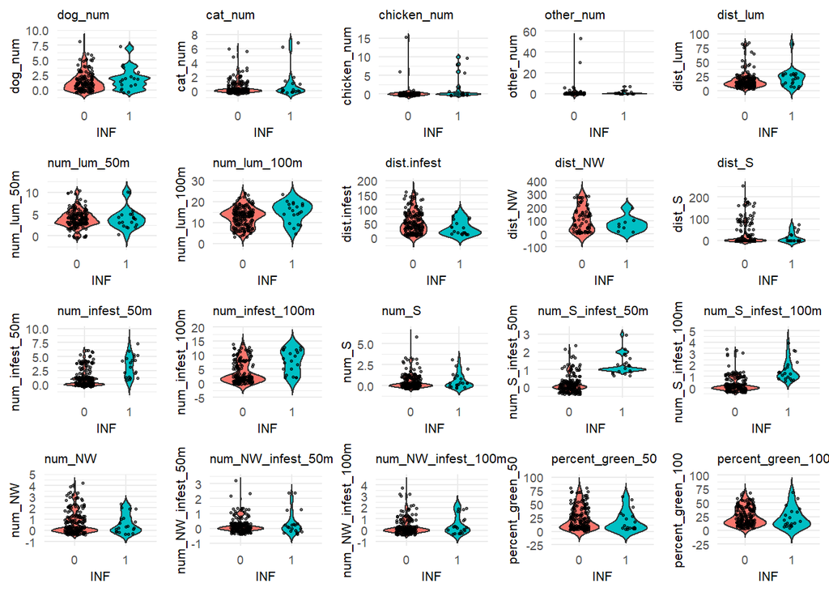

```r
# Function to create violin plots with jittered points
create_violin_plot <- function(data, numeric_var, target_var) {
  # Remove rows with NA in the current numeric variable
  data <- data[!is.na(data[[numeric_var]]), ]

  ggplot(data, aes_string(x = target_var, y = numeric_var, fill = target_var)) +
    geom_violin(trim = FALSE) +
    geom_jitter(width = 0.2, size = 0.6, alpha = 0.6) +
    labs(y = numeric_var, fill = target_var, x = target_var) +
    theme_minimal() +
    theme(
      legend.position = "none",
      plot.title = element_text(size = 8),
      axis.title.x = element_text(size = 8),
      axis.title.y = element_text(size = 8),
      axis.text.x = element_text(size = 7),
      axis.text.y = element_text(size = 7)
    ) +
    ggtitle(numeric_var)
}

# Create list of numeric variables to visualize
numeric_var <- c("dog_num",
                 "cat_num",
                 "chicken_num",
                 "other_num",
                 "dist_lum",
                 "num_lum_50m",
                 "num_lum_100m",
                 "dist.infest",
                 "dist_NW",
                 "dist_S",
                 "num_infest_50m",
                 "num_infest_100m",
                 "num_S",
                 "num_S_infest_50m",
                 "num_S_infest_100m",
                 "num_NW",
                 "num_NW_infest_50m",
                 "num_NW_infest_100m",
                 "percent_green_50",
                 "percent_green_100")


# Create a list to store the plots
num_plots <- list()

# Create plots for each numeric variable and store in the list
for (var in numeric_var) {
  num_plots[[var]] <- create_violin_plot(dbEV, var, "INF")
}

# Arrange the plots in a 4x4 grid
grid.arrange(grobs = num_plots, ncol = 5, nrow = 4)
```

We perform non-parametric Wilcox test for each numerical variable to check for significant associations with the `INF` variable.

```r
# Initialize an empty data frame to store results
results <- data.frame(Variable = character(),
                      p_value = numeric(),
                      stringsAsFactors = FALSE)

# Perform Mann-Whitney test for each numeric variable
for (var in numeric_var) {
  test_result <- wilcox.test(dbEV[[var]] ~ dbEV$INF, data = dbEV)
  results <- rbind(results, data.frame(Variable = var, p_value = test_result$p.value))
}

# Display the results
results <- results %>%
  mutate(Significance = case_when(
    p_value < 0.001 ~ "***",
    p_value < 0.01 ~ "**",
    p_value < 0.05 ~ "*",
    TRUE ~ ""
  ))

# Format p-values to four decimal places
results$p_value <- formatC(results$p_value, format = "f", digits = 4)

# Format the table for Word document
results %>%
  kable("html", col.names = c("Variable", "P-value", "Significance"), align = "c") %>%
  kable_styling(full_width = FALSE, position = "left", bootstrap_options = c("striped", "hover", "condensed")) %>%
  column_spec(1, color = "black") %>%
  column_spec(2, color = "black") %>%
  column_spec(3, bold = TRUE, color = "red") %>%
  row_spec(which(results$Significance != ""), bold = TRUE) %>%
  row_spec(0, bold = TRUE, color = "black")
```

Variable

P-value

Significance

dog_num

0.2355

cat_num

0.4886

chicken_num

0.0000

***

other_num

0.0952

dist_lum

0.0410

num_lum_50m

0.7524

num_lum_100m

0.0203

dist.infest

0.0460

dist_NW

0.5073

dist_S

0.7514

num_infest_50m

0.0000

***

num_infest_100m

0.0000

***

num_S

0.8242

num_S_infest_50m

0.0000

***

num_S_infest_100m

0.0000

***

num_NW

0.8073

num_NW_infest_50m

0.5132

num_NW_infest_100m

0.3501

percent_green_50

0.2281

percent_green_100

0.2740

### Animal host variables.

We first explore the need to create new summary variable for animal hosts. As a first step, we did a correlation matrix with the number of animal hosts.

```r
  # Extract numeric variables related to animals
  animal_vars <- c("dog_num", "cat_num", "chicken_num", "other_num")

  # Compute the Spearman correlation matrix with significance
  library(Hmisc)
  cor_res <- rcorr(as.matrix(dbEV[animal_vars]), type = "spearman")

  # Extract the correlation coefficients and p-values
  cor_matrix <- cor_res$r
  p_matrix <- cor_res$P

  # Set the diagonal elements of both matrices to NA
  diag(cor_matrix) <- NA
  diag(p_matrix) <- NA

  # Format the matrices with three decimal places and no scientific notation
  formatted_cor_matrix <- formatC(cor_matrix, format = "f", digits = 3)
  formatted_p_matrix <- formatC(p_matrix, format = "f", digits = 3)

    # Convert matrices to data frames for better kable formatting
  cor_df <- as.data.frame(formatted_cor_matrix)
  p_df <- as.data.frame(formatted_p_matrix)

  # Create row and column names for clarity
  rownames(cor_df) <- colnames(cor_df) <- animal_vars
  rownames(p_df) <- colnames(p_df) <- animal_vars

  # Print the correlation matrix using kable
  kable(cor_df, caption = "Spearman Correlation Matrix", align = "c") %>%
    kable_styling(full_width = FALSE, position = "left",
                  bootstrap_options = c("striped", "hover", "condensed")) %>%
        column_spec(1:ncol(cor_df), color = "black") %>%
    row_spec(0, color = "black", bold = TRUE)
```

Spearman Correlation Matrix

|  | dog_num | cat_num | chicken_num | other_num |
| --- | --- | --- | --- | --- |
| dog_num | NA | 0.363 | 0.193 | 0.180 |
| cat_num | 0.363 | NA | 0.008 | 0.015 |
| chicken_num | 0.193 | 0.008 | NA | 0.227 |
| other_num | 0.180 | 0.015 | 0.227 | NA |

```r
  # Print the p-value matrix using kable
  kable(p_df, caption = "P-Value Matrix for Spearman Correlations", align = "c") %>%
    kable_styling(full_width = FALSE, position = "left",
                  bootstrap_options = c("striped", "hover", "condensed")) %>%
    column_spec(1:ncol(cor_df), color = "black") %>%
    row_spec(0, color = "black", bold = TRUE)
```

P-Value Matrix for Spearman Correlations

|  | dog_num | cat_num | chicken_num | other_num |
| --- | --- | --- | --- | --- |
| dog_num | NA | 0.000 | 0.012 | 0.021 |
| cat_num | 0.000 | NA | 0.915 | 0.847 |
| chicken_num | 0.012 | 0.915 | NA | 0.003 |
| other_num | 0.021 | 0.847 | 0.003 | NA |

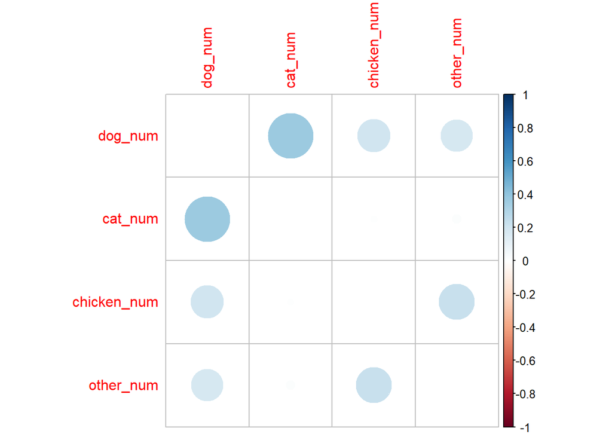

```r
  # Visualize the correlation matrix without the diagonal elements
  corrplot(cor_matrix, method = "circle", na.label = " ")
```

Next we did a factor analysis of mixed data (FAMD) to include numeric and catergorical variables (presence of rats). We didn’t include presence of pigeons in water tanks since none of the infested houses had them.

```r
# Extract the relevant variables, including categorical variables
  famd_vars <- c("dog_num", "cat_num", "chicken_num", "other_num", "rats")

  # Ensure the categorical variables are factors
  dbEV[famd_vars] <- lapply(dbEV[famd_vars], function(x) if(is.character(x)) as.factor(x) else x)

  # Impute missing values using imputeFAMD
  imputed_data <- imputeFAMD(dbEV[famd_vars], ncp = 4) #ncp is the number of dimensions to use for imputation

  # Perform FAMD on the imputed dataset
  famd_res <- FAMD(imputed_data$completeObs, ncp = 4, graph = FALSE)

  # Print the summary of FAMD results
  summary(famd_res)
```

```
##
## Call:
## FAMD(base = imputed_data$completeObs, ncp = 4, graph = FALSE)
##
##
## Eigenvalues
##                       Dim.1  Dim.2  Dim.3  Dim.4
## Variance              1.534  1.052  0.954  0.785
## % of var.            30.685 21.032 19.078 15.690
## Cumulative % of var. 30.685 51.718 70.795 86.485
##
## Individuals (the 10 first)
##                 Dist    Dim.1    ctr   cos2    Dim.2    ctr   cos2    Dim.3
## 3           |  1.201 |  0.397  0.051  0.109 |  0.043  0.001  0.001 | -0.072
## 6           |  1.589 |  0.944  0.289  0.353 |  0.030  0.000  0.000 | -0.139
## 7           |  1.498 | -1.469  0.699  0.961 |  0.087  0.004  0.003 |  0.101
## 8           |  1.450 | -1.395  0.631  0.925 | -0.006  0.000  0.000 |  0.089
## 9           |  1.498 | -1.469  0.699  0.961 |  0.087  0.004  0.003 |  0.101
## 10          |  1.450 | -1.395  0.631  0.925 | -0.006  0.000  0.000 |  0.089
## 11          |  1.498 | -1.469  0.699  0.961 |  0.087  0.004  0.003 |  0.101
## 24          |  1.474 | -0.114  0.004  0.006 | -0.192  0.018  0.017 | -0.019
## 25          |  1.487 | -1.409  0.644  0.898 |  0.189  0.017  0.016 |  0.288
## 26          |  1.201 |  0.397  0.051  0.109 |  0.043  0.001  0.001 | -0.072
##                ctr   cos2
## 3            0.003  0.004 |
## 6            0.010  0.008 |
## 7            0.005  0.005 |
## 8            0.004  0.004 |
## 9            0.005  0.005 |
## 10           0.004  0.004 |
## 11           0.005  0.005 |
## 24           0.000  0.000 |
## 25           0.043  0.037 |
## 26           0.003  0.004 |
##
## Continuous variables
##                Dim.1    ctr   cos2    Dim.2    ctr   cos2    Dim.3    ctr
## dog_num     |  0.757 37.339  0.573 | -0.015  0.022  0.000 | -0.073  0.552
## cat_num     |  0.537 18.775  0.288 | -0.562 29.983  0.315 | -0.069  0.498
## chicken_num |  0.242  3.814  0.059 |  0.727 50.205  0.528 | -0.555 32.316
## other_num   |  0.322  6.764  0.104 |  0.456 19.773  0.208 |  0.796 66.446
##               cos2
## dog_num      0.005 |
## cat_num      0.005 |
## chicken_num  0.308 |
## other_num    0.634 |
##
## Categories
##                 Dim.1     ctr    cos2  v.test     Dim.2     ctr    cos2  v.test
## 0           |  -0.847  15.909   0.685 -10.110 |   0.014   0.009   0.000   0.195
## 1           |   0.926  17.400   0.685  10.110 |  -0.015   0.009   0.000  -0.195
##                 Dim.3     ctr    cos2  v.test
## 0           |   0.040   0.090   0.001   0.598 |
## 1           |  -0.043   0.098   0.001  -0.598 |
```

Visualize the FAMD results

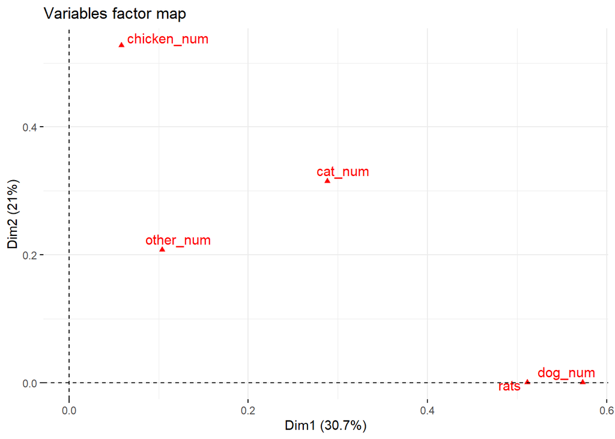

```r
  # Visualize the FAMD results in the first 2 dimensions
    fviz_famd_var(famd_res, repel = TRUE) +
    labs(title = "Variables factor map")
```

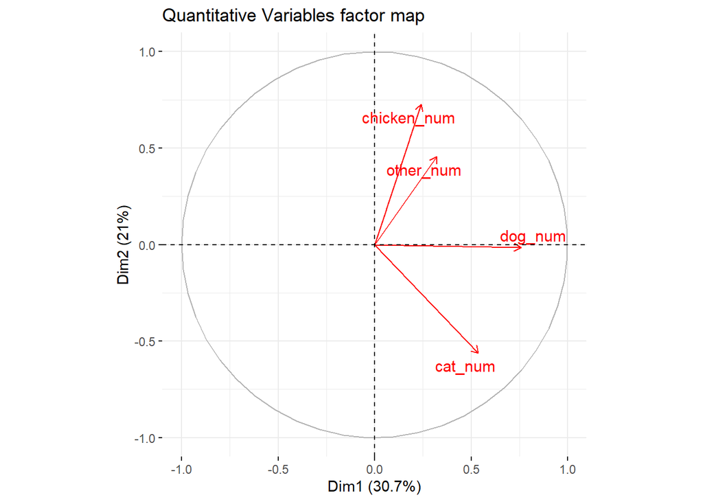

```r
  # Visualize the contributions of quantitative variables
  fviz_famd_var(famd_res, choice = "quanti.var", repel = TRUE) +
    labs(title = "Quantitative Variables factor map")
```

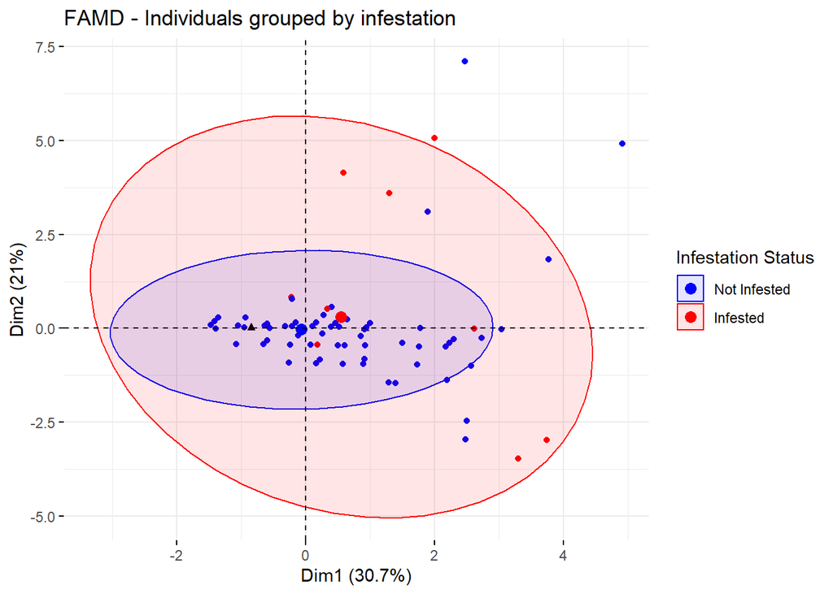

```r
  # Modify INF labels to be more descriptive
  dbEV$INF_label <- factor(dbEV$INF, levels = c(0, 1), labels = c("Not Infested", "Infested"))

  # Visualize the FAMD results with individuals grouped by infestation status

  fviz_famd(famd_res,
               habillage = dbEV$INF_label,        # Use descriptive labels for coloring
               palette = c("blue", "red"),        # Custom colors: "Not Infested" (blue), "Infested" (red)
               repel = TRUE,                      # Avoid overlapping text labels
               addEllipses = TRUE,                # Add confidence ellipses
               label = "none") +                  # Disable individual labels
  labs(title = "FAMD - Individuals grouped by infestation",
       color = "Infestation Status", fill = "Infestation Status") +  # Set a single legend title
  theme(legend.position = "right")
```

Explore the use of PCA for the animal hosts using the numeric variables only

```r
  # Extract the quantitative variables for PCA
  quant_vars <- c("dog_num", "cat_num", "chicken_num", "other_num")
  quant_data <- dbEV[quant_vars]

  # Ensure the data does not contain NA values
  quant_data <- na.omit(quant_data)

  # Perform PCA
  pca_res <- prcomp(quant_data, scale. = TRUE)

  # Print summary of PCA results
  summary(pca_res)
```

```
## Importance of components:
##                           PC1    PC2    PC3    PC4
## Standard deviation     1.1253 1.0276 0.9770 0.8505
## Proportion of Variance 0.3166 0.2640 0.2386 0.1808
## Cumulative Proportion  0.3166 0.5806 0.8192 1.0000
```

```r
  # Extract the quantitative variables for PCA
quant_vars <- c("dog_num", "cat_num", "chicken_num", "other_num")
quant_data <- dbEV[quant_vars]

# Impute missing values using missMDA's PCA-based method
# Estimate the number of dimensions to keep for imputation
ncp <- estim_ncpPCA(quant_data, scale = TRUE)$ncp

# Perform the imputation
imputed_data <- imputePCA(quant_data, ncp = ncp, scale = TRUE)$completeObs

# Perform PCA on the imputed data
pca_res <- prcomp(imputed_data, scale. = TRUE)

# Print summary of PCA results
summary(pca_res)
```

```
## Importance of components:
##                           PC1    PC2    PC3    PC4
## Standard deviation     1.1238 1.0262 0.9770 0.8541
## Proportion of Variance 0.3157 0.2633 0.2386 0.1824
## Cumulative Proportion  0.3157 0.5790 0.8176 1.0000
```

```r
# Extract PCA coordinates (Principal Components)
pca_coords <- as.data.frame(pca_res$x)

# Rename the columns for clarity (e.g., PCA_Dim1, PCA_Dim2, etc.)
colnames(pca_coords) <- paste0("PCA_animal_Dim", 1:ncol(pca_coords))

# Add PCA dimensions back to the original dataset
dbEV <- cbind(dbEV, pca_coords)
```

Visualize the PCA results and evaluate association with infestation

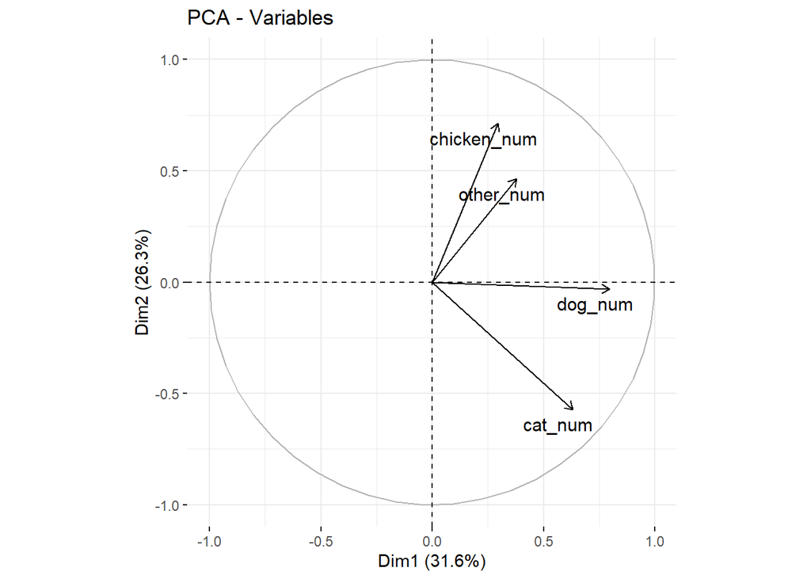

```r
  # Plot variables
  fviz_pca_var(pca_res, repel = TRUE) +
    labs(title = "PCA - Variables")
```

[output not shown]

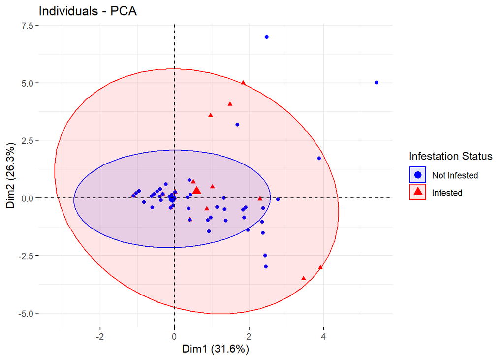

```r
  # Plot individuals with custom colors and descriptive labels in the legend
  fviz_pca_ind(pca_res,
                    geom.ind = "point",               # Plot individuals as points
                    habillage = dbEV$INF_label,       # Use descriptive labels for coloring
                    addEllipses = TRUE,               # Add confidence ellipses
                    palette = c("blue", "red"),       # Custom colors: "Not Infested" (blue), "Infested" (red)
                    legend.title = "Infestation Status", # Set a single legend title
                    label = "none") +                 # Disable individual labels
    scale_color_manual(values = c("Not Infested" = "blue", "Infested" = "red")) +  # Ensure consistent color mapping
    theme(legend.position = "right")                # Position legend on the right
```

```r
  # Define all variables for Mann-Whitney U tests
  all_vars <- c(colnames(pca_coords))
  # Remove variables containing "NA"
  all_vars <- subset(all_vars, !is.na(all_vars))

  # Initialize an empty data frame to store results
  results <- data.frame(Variable = character(),
                        p_value = numeric(),
                        Significance = character(),
                        stringsAsFactors = FALSE)

  # Perform Mann-Whitney test for each variable
  for (var in all_vars) {
    test_result <- wilcox.test(dbEV[[var]] ~ dbEV$INF, data = dbEV)
    results <- rbind(results, data.frame(Variable = var,
                                         p_value = formatC(test_result$p.value, format = "f", digits = 4),
                                         Significance = ifelse(test_result$p.value < 0.05, ifelse(test_result$p.value < 0.01, ifelse(test_result$p.value < 0.001, "***", "**"), "*"), "")))
  }

  # Format p-values to four decimal places
results$p_value <- formatC(results$p_value, format = "f", digits = 4)

# Format the table for Word document
results %>%
  kable("html", col.names = c("Variable", "P-value", "Significance"), align = "c") %>%
  kable_styling(full_width = FALSE, position = "left", bootstrap_options = c("striped", "hover", "condensed")) %>%
  column_spec(1, color = "black") %>%
  column_spec(2, color = "black") %>%
  column_spec(3, bold = TRUE, color = "red") %>%
  row_spec(which(results$Significance != ""), bold = TRUE) %>%
  row_spec(0, bold = TRUE, color = "black")
```

Variable

P-value

Significance

PCA_animal_Dim1

0.0233

PCA_animal_Dim2

0.3070

PCA_animal_Dim3

0.0159

PCA_animal_Dim4

0.0591

### House construction variables

We used cluster analyses to build “house type” variable based on the construction materials (roof and wall materials and characteristics). We first did a multiple correspondence analyses (MCA), to sumarize the categorical variables in orthogonal numeric variables to be used in the cluster analyses.

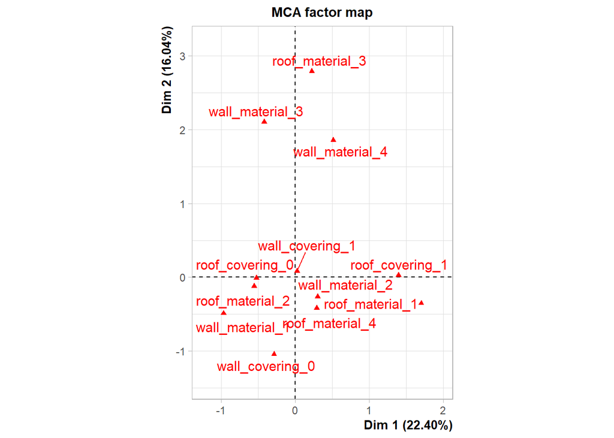

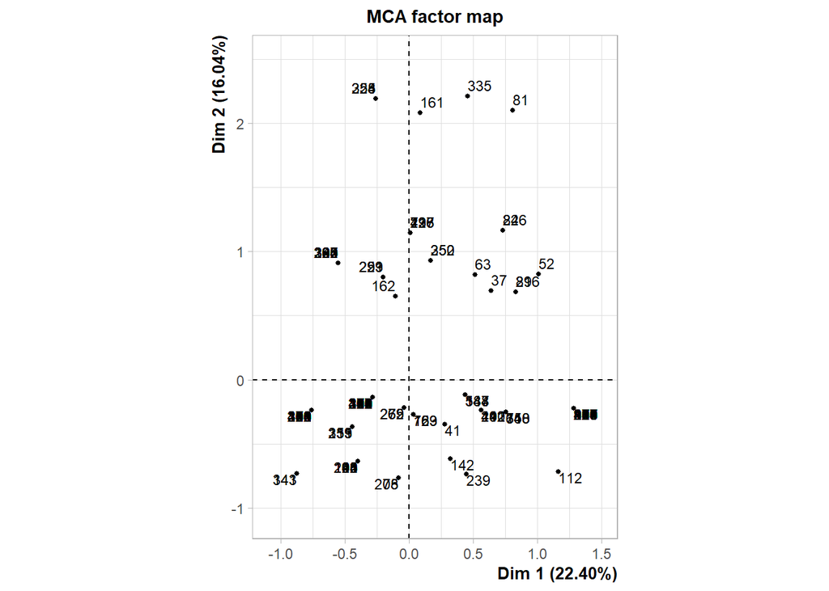

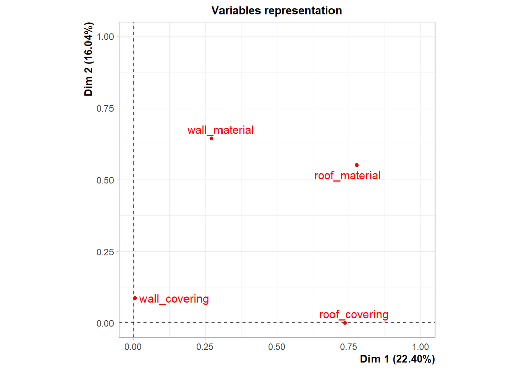

```r
  # Define the variables related to house type
  house_vars <- c("wall_material", "wall_covering", "roof_material", "roof_covering")

  # Ensure the variables are treated as factors
  dbEV[house_vars] <- lapply(dbEV[house_vars], as.factor)

  # Impute missing values
  imputed_data <- imputeMCA(dbEV[house_vars], ncp = 3)

  # Perform Multiple Correspondence Analysis (MCA) on imputed data
  mca_res <- MCA(imputed_data$completeObs, graph = TRUE)
```

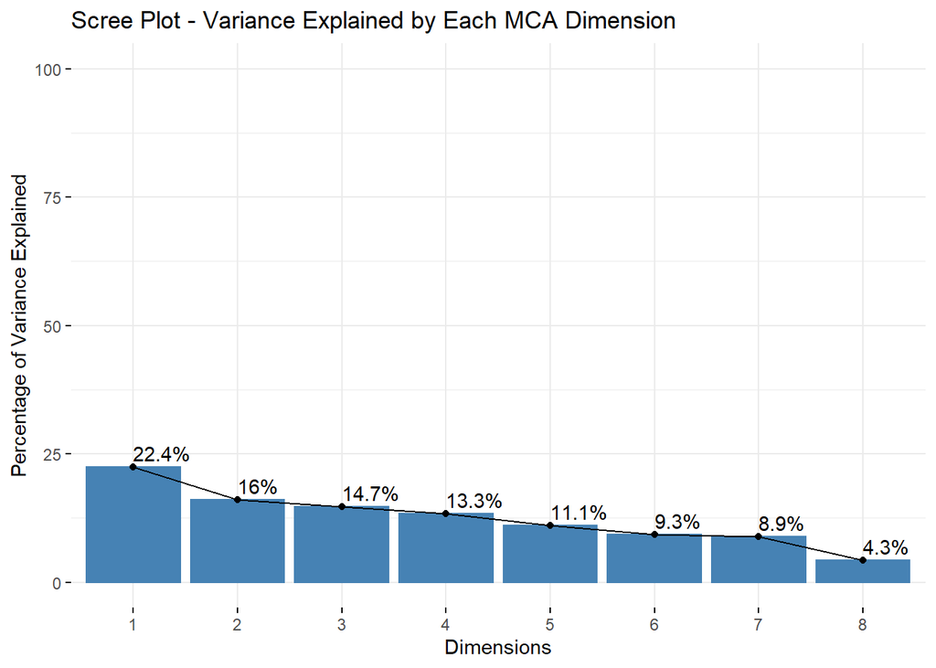

```r
  # Extract MCA coordinates for individuals
  mca_coords <- as.data.frame(mca_res$ind$coord)
  colnames(mca_coords) <- paste0("MCA_Dim", 1:ncol(mca_coords))

  # Combine the original data frame with the MCA results
  dbEV <- cbind(dbEV, mca_coords)

  # Create a scree plot to visualize the variance explained by each dimension
fviz_screeplot(mca_res, addlabels = TRUE, ylim = c(0, 100)) +
  labs(title = "Scree Plot - Variance Explained by Each MCA Dimension",
       x = "Dimensions", y = "Percentage of Variance Explained")
```

We then performed a hierarchical clustering analyses with the first 5 dimensions (~77% of the variance)

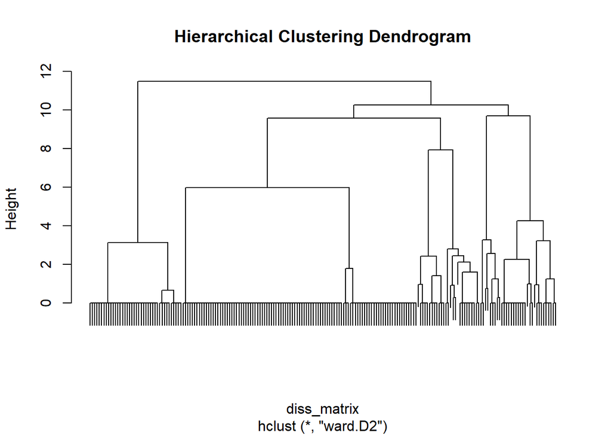

```r
  # Perform hierarchical clustering
  diss_matrix <- daisy(mca_coords, metric = "euclidean")
  hc_res <- hclust(diss_matrix, method = "ward.D2")

  # Plot the dendrogram
  plot(hc_res, labels = FALSE, main = "Hierarchical Clustering Dendrogram")
```

```r
  # Cut the dendrogram to obtain 3 clusters
  clusters <- cutree(hc_res, k = 3)

  # Create a table summarizing the clusters
  cluster_table <- data.frame(Cluster = clusters, dbEV[house_vars])
  print("Cluster summary table:")
```

```
## [1] "Cluster summary table:"
```

```r
  print(table(cluster_table$Cluster))
```

```
##
##   1   2   3
## 128  40  33
```

```r
  # Add the cluster assignments as a new categorical variable to dbEV
  dbEV$house_type <- as.factor(clusters)
```

Next, we visualized the clusters (type of house) based on the MCA variables, and charectized the clusters based on the construction characteristics of the houses.

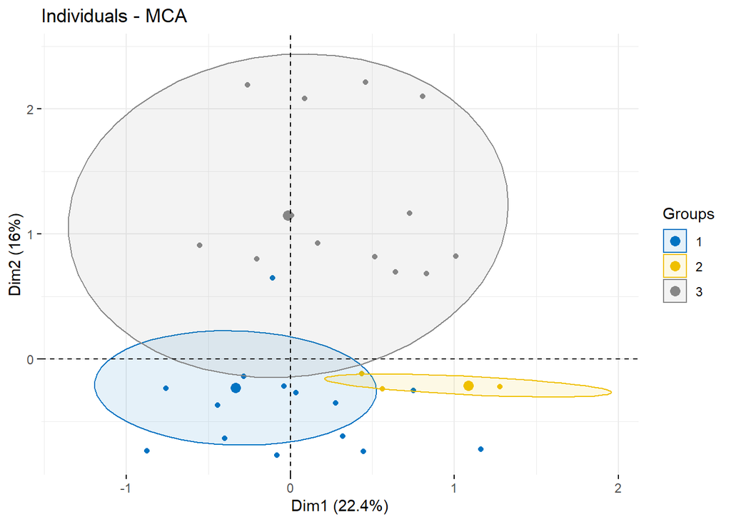

```r
  # Plot the individuals colored by house_type
  fviz_mca_ind(mca_res,
               label = "none",         # Hide individual labels
               habillage = dbEV$house_type,   # Color by house_type
               addEllipses = TRUE,     # Add confidence ellipses
               ellipse.level = 0.95,   # Confidence level
               palette = "jco")        # Color palette
```